# Analysis of Vancouver TransLink Ridership

# Analysis of Vancouver TransLink Ridership

Report by: Tomasz Puzio

Student ID: 100904335

Date: April 2026

## Introduction

The data in this report is sourced from TransLink’s Transit Service Performance Review (TSPR). I chose to compare datasets containing 2019 (pre-pandemic) and 2024 (current) ridership to see how the region’s transit habits have changed permanently. TSPR source data does **not** include ridership numbers for 2020 or 2021, thus bypassing ridership levels for the initial pandemic years, instead focusing on pre-pandemic, and the “new normal” for TransLink’s network.

The datasets chosen provide a complete look at ridership for individual bus stops, SkyTrain station annual boardings, and the geographic coordinates required to map the system. My analysis primarily explores whether or not the network has fully recovered to its 2019 peak. While a high-level view shows that many of TransLink’s services still fall short of their pre-pandemic levels, a closer look reveals a shift in **when** and **where** people are riding. To investigate further, I focused on four key questions:

1. **Regional Recovery:** Which regions have recovered, which are lagging?
2. **Density vs. Demand:** Do population and employment counts predict how busy a station will be in 2024?
3. **Inter modal Connectivity:** How important are “transfer points” in funneling bus riders into the SkyTrain network?
4. **Operational Reliability:** Does a bus’s size or type (i.e. articulated vs. double decker) impact its ability to stay on schedule?

The visualizations I chose show a system that is evolving from a downtown-centric commute, to a diverse, regional network.

## Library Imports

```r
library(tidyverse)
library(sf)
library(maptiles)
library(tidyterra)
library(ggridges)
library(viridis)
```

## Regional Recovery

> Which regions have recovered? Which are lagging?

### Plot 1 - Heatmap

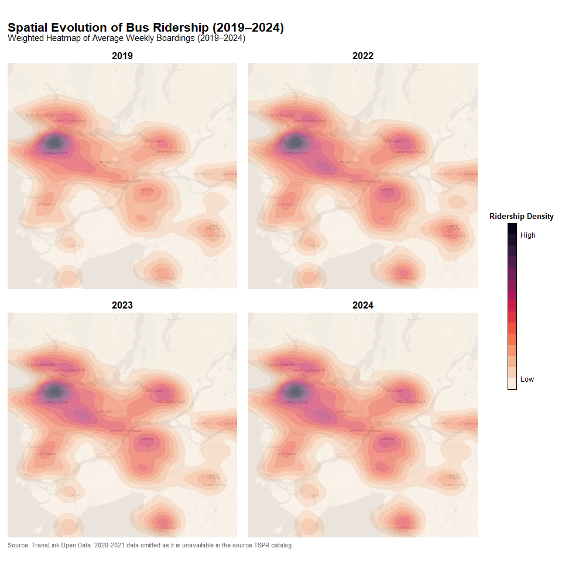

```r
# Load ridership data.
stops <- read_csv("data/TransLink_Bus_Stop_Ridership_2019_2024.csv")

# Data manipulation, converting to spatial features.
stops_sf <- stops |>
  st_as_sf(coords = c("Stop_Longitude", "Stop_Latitude"), crs = 4326) |>
  st_transform(32610) |> # Transform to UTM for accurate spatial calculations.
  # Create a 'Weekly Total' metric for weighting the heatmap.
  mutate(Stop_Avg_Daily_Boardings_Week = Stop_Avg_Daily_Boardings_MF +
           Stop_Avg_Daily_Boardings_Sat +
           Stop_Avg_Daily_Boardings_SunHol) |>
  filter(!is.na(Stop_Avg_Daily_Boardings_Week))

# Extract projected coordinates for the 2D density function.
coords <- st_coordinates(stops_sf)
stops_sf_coords <- stops_sf |>
  mutate(lon = as.numeric(coords[,1]), lat = as.numeric(coords[,2]))

# Fetch background tiles for geographic context.
bg_tiles_bus <- get_tiles(stops_sf, provider = "CartoDB.Positron", zoom = 11)

# Visualization: 2D Density Heatmap faceted by Year.
ggplot(stops_sf_coords) +

  geom_spatraster_rgb(data = bg_tiles_bus) +

  # Use stat_density_2d to show ridership 'hotspots' weighted by boardings.
  stat_density_2d_filled(aes(x = lon,
                             y = lat,
                             fill = after_stat(level),
                             weight = Stop_Avg_Daily_Boardings_Week),
                         alpha = 0.6,
                         bins = 15,
                         contour_var = "ndensity") +

  scale_fill_viridis_d(option = "rocket",
                       direction = -1,
                       labels = c("Low", rep("", 12), "High")) +

  # Temporal comparison.
  facet_wrap(~TSPR_Year) +

  coord_sf(xlim = c(482000, 530000),
           ylim = c(5428000, 5475000),
           expand = FALSE) +

  # Clean aesthetic for spatial data.
  theme_void() +

  theme(
    legend.position = "right",
    legend.title = element_text(size = 10, face = "bold", margin = margin(b = 5)),
    legend.margin = margin(l = 10),
    legend.key.width = unit(0.4, "cm"),
    legend.key.height = unit(1.5, "cm"),

    strip.text = element_text(face = "bold", size = 12, margin = margin(b = 5)),
    plot.title.position = "plot",
    plot.title    = element_text(hjust = 0, face = "bold", size = 16),
    plot.subtitle = element_text(hjust = 0, size = 11, margin = margin(b = 10)),
    plot.caption  = element_text(hjust = 0, color = "grey40", size = 8),

    plot.margin = margin(t = 10, r = 10, b = 5, l = 10),
    panel.spacing = unit(1, "lines")
  ) +

  guides(fill = guide_coloursteps(
    title = "Ridership Density",
    title.position = "top",
    title.hjust = 0.5,
    ticks = FALSE,
    frame.colour = "black",
    frame.linewidth = 0.2,
    show.limits = TRUE,
    direction = "vertical"
  )) +

  labs(title = "Spatial Evolution of Bus Ridership (2019–2024)",
       subtitle = "Weighted Heatmap of Average Weekly Boardings (2019–2024)",
       caption = "Source: TransLink Open Data. 2020-2021 data omitted as it is unavailable in the source TSPR catalog.")
```

### Plot 2 - Dumbbell Plot

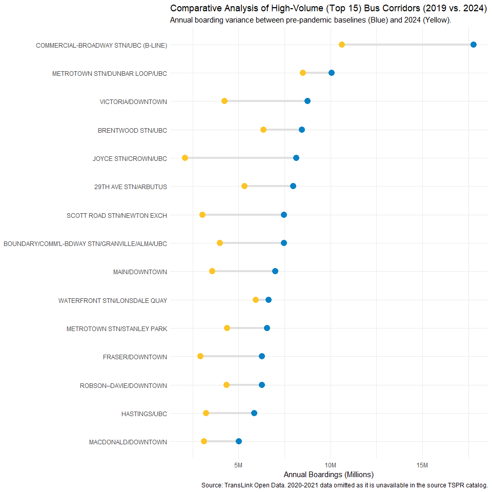

```r
# Load and transform bus performance data for temporal comparison.
ridership <- read_csv("data/TransLink_Bus_Line_With_Connections.csv") |>

  # Filter for 2019 and 2024 to evaluate long-term recovery.
  filter(TSPR_Year %in% c(2019, 2024)) |>
  select(Line, Line_Name, TSPR_Year, Annual_Boardings) |>
  group_by(Line, TSPR_Year) |>
  summarise(
    Annual_Boardings = sum(Annual_Boardings),
    .groups = "drop"
  ) |>

  # Reshape data from 'Long' to 'Wide' for dumbbell visualization.
  pivot_wider(
    names_from = TSPR_Year,
    values_from = Annual_Boardings,
    names_prefix = "y"
  ) |>
  drop_na(y2019, y2024) |>

  # Focus on high-impact routes.
  slice_max(y2019, n = 15) |>

  # Join names to ensure descriptive y-axis labels.
  left_join(
    read_csv("data/TransLink_Bus_Line_With_Connections.csv") |>
      filter(TSPR_Year == 2019) |>
      distinct(Line, Line_Name),
    by = "Line"
  )

# Visualization: Dumbbell Plot comparing pre-pandemic vs current volumes.
ggplot(ridership, aes(y = fct_reorder(Line_Name, y2019))) +

  # The 'dumbbell' bar represents the magnitude of the ridership gap
  geom_segment(aes(x = y2019, xend = y2024, yend = Line_Name),
               color = "#e0e0e0", size = 1.5) +

  # 2019 Baseline Point.
  geom_point(aes(x = y2019), color = "#0881c4", size = 4) +

  # 2024 Current Volume Point.
  geom_point(aes(x = y2024), color = "#fdc427", size = 4) +

  # Format x-axis for millions.
  scale_x_continuous(labels = label_number(suffix = "M", scale = 1e-6)) +

  theme_minimal() +

  labs(
    title = "Comparative Analysis of High-Volume (Top 15) Bus Corridors (2019 vs. 2024)",
    subtitle = "Annual boarding variance between pre-pandemic baselines (Blue) and 2024 (Yellow).",
    caption = "Source: TransLink Open Data. 2020-2021 data omitted as it is unavailable in the source TSPR catalog.",
    x = "Annual Boardings (Millions)",
    y = NULL
  )
```

I utilized a dumbbell plot to visualize the ridership variance between pre-pandemic (2019) baselines and the 2024 “new normal.” This format is able ot clearly outline the change in magnitude for individual routes. The data clearly shows that while some corridors are nearing their pre-pandemic levels, TransLinks top 15 busiest bus routes have yet to fully recover.

## Density vs. Demand

> Do population and employment counts predict how busy a station will be in 2024?

### Plot 3 - Bubble Map

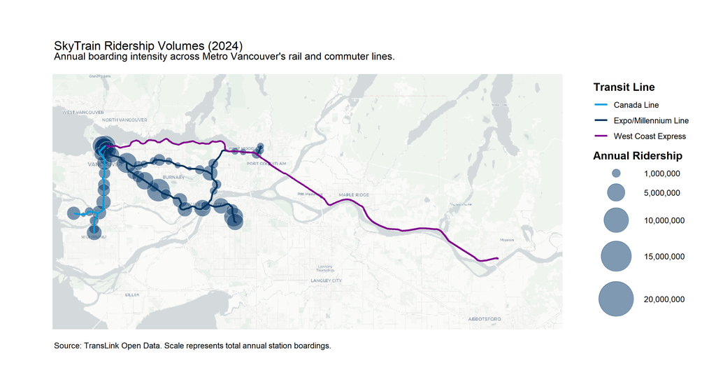

```r
# Load spatial data for rail infrastructure.
stations_sf <- st_read("data/TransLink_SkyTrain_Stations_Geo/Rail_Station.shp") |>
  st_transform(crs = 4326)
lines_sf <- st_read("data/TransLink_SkyTrain_Lines_Geo/Rail_Line.shp") |>
  st_transform(crs = 4326)
# Define official TransLink brand colors for visual consistency.
line_Colours <- c("Canada Line" = "#009ddc", "Expo/Millennium Line" = "#00355f", "West Coast Express" = "#820c8e")

# Generate geographic background tiles using CartoDB provider.
bg_tiles <- get_tiles(stations_sf, provider = "CartoDB.Positron", zoom = 11)

ggplot() +
  # Layer 1: Background Tiles.
  geom_spatraster_rgb(data = bg_tiles) +

  # Layer 2: Station Bubbles, Size represents volume.
  geom_sf(data = stations_sf,
          aes(size = Annual_Boa),
          fill = "#003366",
          colour = "white",
          stroke = 0.5,
          alpha = 0.5,
          shape = 21) +

  # Layer 3: Rail Lines.
  geom_sf(data = lines_sf,
          aes(colour = Line),
          linewidth = 1,
          show.legend = "line") +

  # Manual scales for professional branding and readable numbers.
  scale_colour_manual(values = line_Colours,
                      name = "Transit Line") +

  scale_size_area(max_size = 20,
                  breaks = c(1e6, 5e6, 10e6, 15e6, 20e6),
                  limits = c(0, 25000000),
                  labels = label_comma(),
                  name = "Annual Ridership",
                  guide = guide_legend(
                    override.aes = list(colour = "#003366",
                                        linetype = 0)
                  )) +

  theme_void() +

  theme(
    # Ensure titles are flush with the left margin.
    plot.title.position  = "plot",
    plot.caption.position = "plot",

    # Text Styling.
    plot.title    = element_text(hjust = 0, margin = margin(l = 30)),
    plot.subtitle = element_text(hjust = 0, margin = margin(l = 30)),
    plot.caption  = element_text(hjust = 0, margin = margin(l = 30)),

    # Legend Styling.
    legend.position = "right",
    legend.title = element_text(face = "bold", size = 12),

    # Margin Adjustment to prevent clipping.
    plot.margin = margin(t = 30, r = 30, b = 30, l = 30)
  ) +

  labs(
    title    = "SkyTrain Ridership Volumes (2024)",
    subtitle = "Annual boarding intensity across Metro Vancouver's rail and commuter lines.",
    caption  = "Source: TransLink Open Data. Scale represents total annual station boardings."
  )
```

I used a bubble map to visualize ridership “gravity,” where the bubble size corresponds to annual station boardings. This visualization confirms that the Expo and Millennium Lines serve the system’s key high-volume arteries, both outperforming the Canada Line. To contrast this, the West Coast Express shows significantly lower intensity, highlighting its role as a niche peak-period commuter rail service instead of a high-frequency urban transit anchor.

## Inter-modal Connectivity

> How important are “transfer points” in funneling bus riders into the SkyTrain network?

### Plot 4 - Stacked Bar Chart

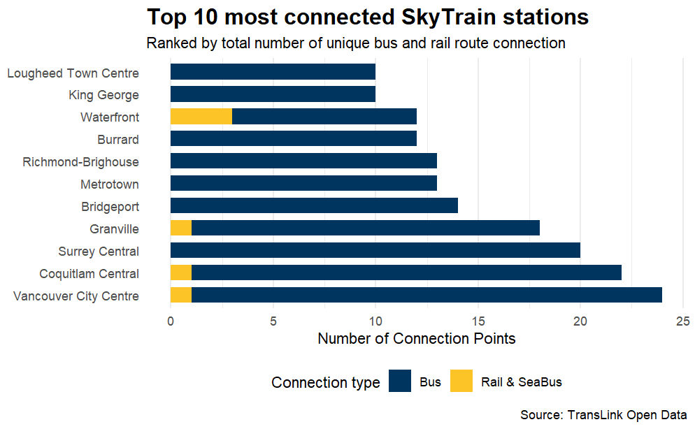

```r
# Data Manipulation: Quantifying network connectivity.
connections <- read_csv("data/TransLink_SkyTrain_Stations.csv") |>
  group_by(Name) |>
  slice(1) |> # Ensure each station name appears only once.
  ungroup() |>
  mutate(
    # Count semicolons in the connection string to calculate the number of routes.
    Total_Bus_Connections = str_count(Route_Connections, ";") + 1,
    Total_Rail_SeaBus_Connections = str_count(
      str_remove(Rail_SeaBus_Connections, fixed(Line)),
      ";"
    ),
    # Combine metrics for a 'Grand Total' of intermodal connectivity.
    Total_Connections = Total_Bus_Connections + Total_Rail_SeaBus_Connections
  ) |>

  # Select the most connected for the visualization.
  slice_max(Total_Connections, n = 10) |>
  # Clean up station names and reorder for a clean descending bar chart.
  mutate(Name = str_remove(Name, " Station"),
         Name = fct_reorder(Name, Total_Connections, .desc = TRUE)) |>

  # Pivot to 'Long' format for stacked bar rendering.
  pivot_longer(
    cols = c(Total_Bus_Connections, Total_Rail_SeaBus_Connections),
    names_to = "Connection_Type",
    values_to = "Count"
  ) |>
  mutate(
    Connection_Type = recode(Connection_Type,
                             "Total_Bus_Connections" = "Bus",
                             "Total_Rail_SeaBus_Connections" = "Rail & SeaBus"
                             )
  )

# Visualization: Intermodal Connectivity Hubs.
ggplot(connections, aes(x = Name, y = Count, fill = Connection_Type)) +
  geom_col(width = 0.7) +
  coord_flip() + # Flip for better readability of station names.

  # Applying color palette.
  scale_fill_manual(values = c("Bus" = "#00355f", "Rail & SeaBus" = "#fdc427")) +
  theme_minimal() +
  theme(
    panel.grid.major.y = element_blank(), # Remove horizontal grid lines for focus.
    plot.title = element_text(face = "bold", size = 16),
    legend.position = "bottom"
  ) +
  labs(
    title = "Top 10 most connected SkyTrain stations",
    subtitle = "Ranked by total number of unique bus and rail route connection",
    x = NULL,
    y = "Number of Connection Points",
    fill = "Connection type",
    caption = "Source: TransLink Open Data"
  )
```

I used a stacked bar chart to analyze the importance of transfer hubs, differentiating between bus and rail/SeaBus connections in order to identify the networks main “feeder” points. The data highlights Vancouver City Centre as the system’s bus-volume leader, funneling riders into the downtown core and connecting them to various bus routes across the city. Waterfront station stands out as the most “multi-modal” hub, providing riders with connections to the rail network, and most notably, the SeaBus service.

### Plot 5 - Multivariate Scatter Plot

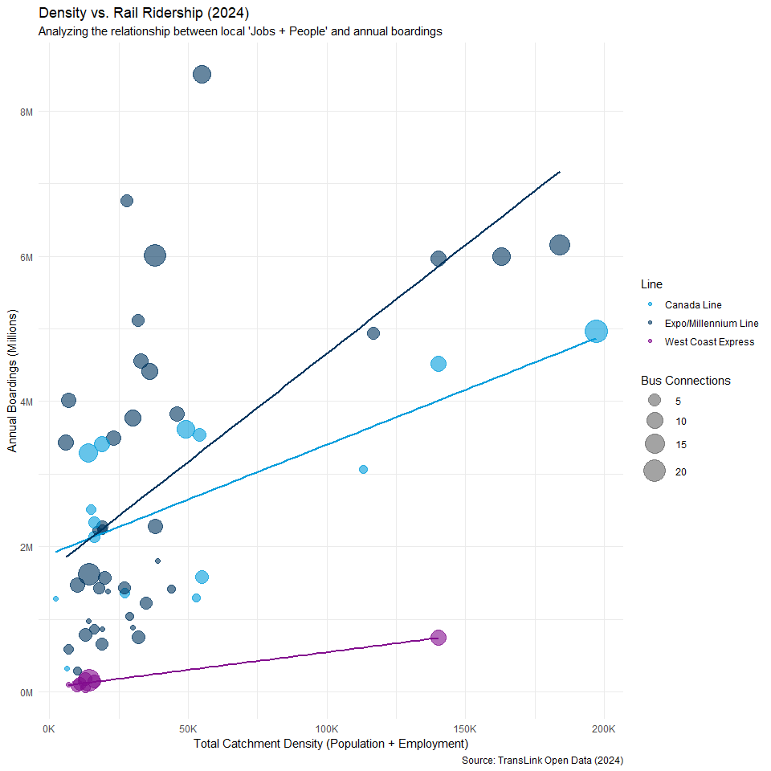

```r
# Data Manipulation: Integrating land use and transit metrics.
density <- read_csv("data/TransLink_SkyTrain_Stations.csv") |>
  # Create a new column Jobs + Residents.
  mutate(Pop_Emp = Population + Employment,
         # Quantify intermodal connectivity for use as a sizing variable.
         Total_Bus_Connections = str_count(Route_Connections, ";") + 1) |>
  # Ensure only stations with valid census/employment data are included.
  filter(!is.na(Pop_Emp))

# TransLink Branding.
Line_Colours <- c("Canada Line" = "#009ddc", "Expo/Millennium Line" = "#00355f", "West Coast Express" = "#820c8e")

# Visualization: Multivariate Scatter Plot.
ggplot(density, aes(x = Pop_Emp, y = Annual_Boardings, colour = Line, size = Total_Bus_Connections)) +

  # Use alpha for overlapping points to visualize 'clumps' of stations.
  geom_point(alpha = 0.6) +

  # Format axes for readability.
  scale_x_continuous(
    labels = label_number(suffix = "K", scale = 1e-3),
    limits = c(0, NA),
    expand = expansion(mult = c(0.02, 0.05))
  ) +

  scale_y_continuous(labels = label_number(suffix = "M", scale = 1e-6)) +

  # Add linear regression models to analyze prediction trends.
  geom_smooth(method = "lm", se = FALSE, aes(size = NULL, group = Line), linewidth = 0.8, show.legend = FALSE) +

  # Distinguish bus connectivity hubs through bubble scaling.
  scale_size_continuous(range = c(2, 10), name = "Bus Connections") +

  scale_colour_manual(values = Line_Colours) +

  # Styling the legend for clarity.
  guides(
    size = guide_legend(override.aes = list(colour = "grey40", fill = "grey40"))
  ) +

  labs(
    title = "Density vs. Rail Ridership (2024)",
    subtitle = "Analyzing the relationship between local 'Jobs + People' and annual boardings",
    caption = "Source: TransLink Open Data (2024)",
    x = "Total Catchment Density (Population + Employment)",
    y = "Annual Boardings (Millions)"
  ) +
  theme_minimal()
```

I chose a multivariate scatter plot to to show how local density and bus connections together drive SkyTrain ridership. The trend lines show a clear positive correlation, but several “outlier” stations with lower local density still achieve massive ridership. This shows that a station’s role as a bus-to-rail reeder hub can be even more important for its success than the number of people living or working near it.

### Plot 6 - Ridge Plot

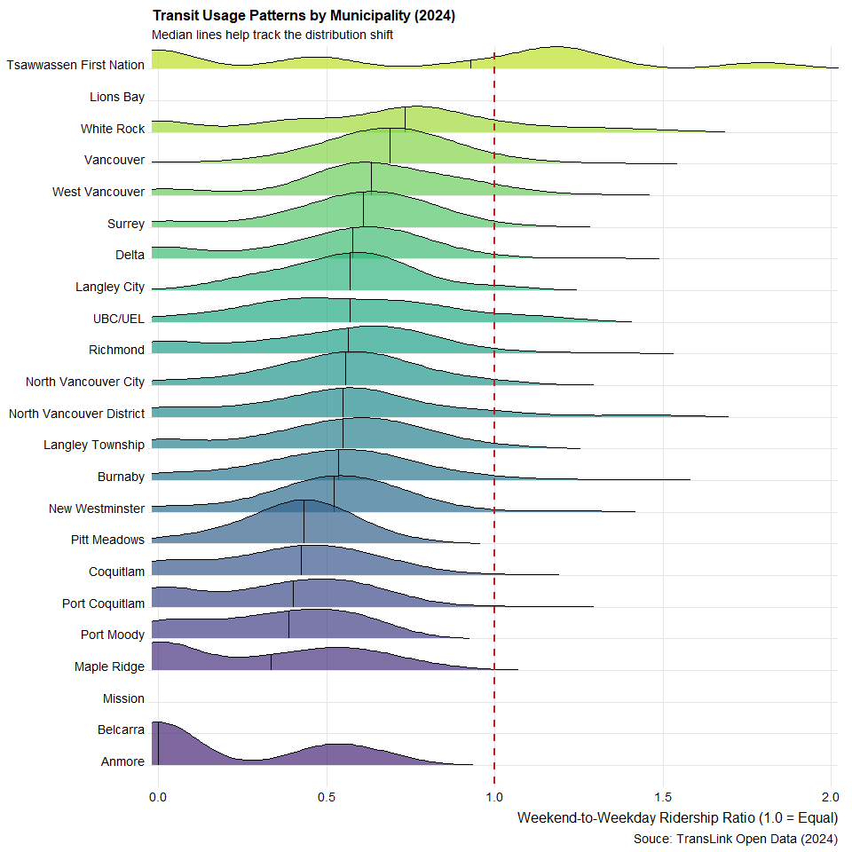

```r
# Data Manipulation: Analyzing service character across regions.
bus_ridership <- read_csv("data/TransLink_Bus_Stop_Ridership_2019_2024.csv") |>

  # Focus on the most recent complete data year (2024).
  filter(TSPR_Year == 2024) |>
  mutate(
    # Create a 'Weekend Average' by weighting Saturday and Sunday/Holiday data.
    weekend_avg = (Stop_Avg_Daily_Boardings_Sat + Stop_Avg_Daily_Boardings_SunHol) / 2,
    # Calculate the ratio of weekend-to-weekday usage to identify 'Leisure Hubs'.
    weekend_ratio = weekend_avg / Stop_Avg_Daily_Boardings_MF
  ) |>

  # Remove stops with zero weekday activity to avoid infinite ratios.
  filter(Stop_Avg_Daily_Boardings_MF > 0 & !is.na(weekend_ratio)) |>
  filter(!is.na(Municipality)) |>
  # Reorder factor levels by median ratio for a clean visualization.
  mutate(Municipality = fct_reorder(Municipality, weekend_ratio, .fun = median))

# Visualization: Distribution of ridership behavior.
ggplot(bus_ridership, aes(x = weekend_ratio, y = Municipality, fill = Municipality)) +
  # Use ridges to show the 'spread' of behavior within each city.
  geom_density_ridges(
    alpha = 0.7,
    scale = 1.2,
    rel_min_height = 0.01,
    quantile_lines = TRUE,
    quantiles = 2,
    boundary = 0
  ) +

  scale_fill_viridis_d(option = "viridis", begin = 0.1, end = 0.9) +
  scale_x_continuous(breaks = seq(0, 2, 0.5), expand = c(0.01, 0)) +

  theme_ridges(font_size = 12, grid = TRUE) +

  # Reference line: 1.0 represents equal ridership on weekends and weekdays.
  geom_vline(xintercept = 1.0, linetype = "dashed", color = "firebrick", linewidth = 0.8) +

  labs(
    title = "Transit Usage Patterns by Municipality (2024)",
    subtitle = "Median lines help track the distribution shift",
    x = "Weekend-to-Weekday Ridership Ratio (1.0 = Equal)",
    y = NULL,
    caption = "Souce: TransLink Open Data (2024)"
  ) +

  theme(
    legend.position = "none",
    panel.spacing = unit(0.5, "lines"),
    plot.title = element_text(face = "bold"),
  ) +

  coord_cartesian(xlim = c(0, 2))
```

## Operational Reliability

> Does a bus’s size or type (i.e. articulated vs. double decker) impact its ability to stay on schedule?

### Plot 7 - Lollipop Chart

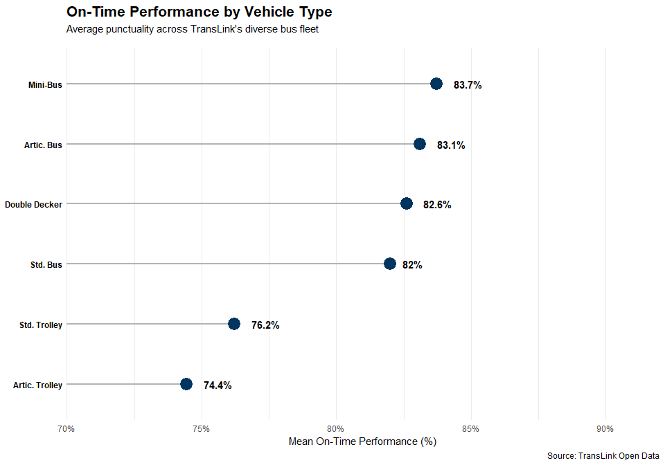

```r
# Data Manipulation: Analyzing service reliability by fleet type.
bus <- read.csv("data/TransLink_Bus_Line_With_Connections.csv")

bus_summary <- bus |>
  # Clean string data by removing '%' and converting to numeric.
  mutate(On_Time_Performance_Percentage = as.numeric(gsub("%", "", On_Time_Performance_Percentage))) |>

  # Filter out non-bus modes to focus on road fleet performance.
  filter(Predominant_Vehicle_Type != "SeaBus") |>
  group_by(Predominant_Vehicle_Type) |>

  # Aggregate performance data to identify trends by vehicle class.
  summarize(Mean_Performance = mean(On_Time_Performance_Percentage, na.rm = TRUE)) |>
  # Reorder for descending ranking.
  mutate(Predominant_Vehicle_Type = reorder(Predominant_Vehicle_Type, Mean_Performance))


# Visualization: Lollipop Chart of Reliability.
ggplot(bus_summary, aes(x = Mean_Performance, y = Predominant_Vehicle_Type)) +

  # Draw the 'stick' of the lollipop for visual guidance.
  geom_segment(aes(x = 70, xend = Mean_Performance, yend = Predominant_Vehicle_Type),
               colour = "grey70", size = 0.8) +

  # Draw the 'candy' (data point).
  geom_point(size = 6, colour = "#00355f") +

  # Add direct labels to points to improve scannability.
  geom_text(aes(label = paste0(round(Mean_Performance, 1), "%")),
            hjust = -0.6, size = 4, fontface = "bold") +

  # Format axis with percentage labels and specific limits.
  scale_x_continuous(labels = function(x) paste0(x, "%"),
                     limits = c(70, 92),
                     expand = c(0,0)) +

  labs(
    title = "On-Time Performance by Vehicle Type",
    subtitle = "Average punctuality across TransLink's diverse bus fleet",
    x = "Mean On-Time Performance (%)",
    y = NULL,
    caption = "Source: TransLink Open Data"
  ) +

  theme_minimal() +

  theme(
    panel.grid.major.y = element_blank(),
    plot.title = element_text(face = "bold", size = 16),
    plot.subtitle = element_text(size = 11, margin = margin(b = 15)),
    axis.text.y = element_text(face = "bold", color = "black")
  )
```

I used a lollipop chart to rank on-time performance across TransLink’s fleet, revealing a distinct gap between vehicles used in the urban-core compared to local buses. While Mini-buses lead in reliabiliy due to their use on lower-traffic suburban routes, Trolley and Articulated Trolley buses show significantly lower on-time performance, dropping below the 77% mark. This is likely due to the geographic constraints of the trolley network, which primarily operated in congested downtown corridors where traffic-related delays are more common.

### Sources

https://experience.arcgis.com/experience/bedca58037104e468cbcf97aa38ca602

https://www.arcgis.com/home/item.html?id=11b5561d409843a0ae27f8b490f9dda9

### AI - Prompts

> Please add brief comments to this code.